# Further Hypothesis Testing

```python
# Select this cell and type Ctrl-Enter to execute the code below.

import numpy as np
import pandas as pd
from scipy import stats
import matplotlib.pyplot as plt
```

## 1 - Introduction

In this workshop, you will apply a number of commonly encountered parametric and non-parametric tests to answer a variety of research questions about an example data set.

We begin with a brief exploration of the data.

### Data set

The file `stars.csv` contains a dataset of 240 stars, with five variables for each star:

| variable | description |
| --- | --- |
| temperature | the surface temperature (K) |
| luminosity | luminosity relative to sun |
| radius | radius relative to sun |
| spectral_class | the spectral class of each star (O,B,A,F,G,K or M) |
| type | as defined below |

The luminosity and radius of each star is calculated relative to that of the Sun:

$L_{sun} = 3.83 \times 10^{26}\text{W}$

$R_{sun} = 6.96 \times 10^8\text{m}$

The stars are classified into 6 types:

| code | type |
| --- | --- |
| 0 | Brown Dwarf |
| 1 | Red Dwarf |
| 2 | White Dwarf |
| 3 | Main Sequence |
| 4 | Supergiant |
| 5 | Hypergiant |

The dataset contains 40 examples of each type.

Load the data using the `pandas` library:

```python
data = pd.read_csv("stars.csv")
type_key = ['Brown Dwarf', 'Red Dwarf', 'White Dwarf', 'Main Sequence', 'Supergiant','Hypergiant']

data.head()
```

|  | temperature | luminosity | radius | spectral_class | type |
| --- | --- | --- | --- | --- | --- |
| 0 | 3068 | 0.002400 | 0.1700 | M | 0 |
| 1 | 3042 | 0.000500 | 0.1542 | M | 0 |
| 2 | 2600 | 0.000300 | 0.1020 | M | 0 |
| 3 | 2800 | 0.000200 | 0.1600 | M | 0 |
| 4 | 1939 | 0.000138 | 0.1030 | M | 0 |

We will be using histogram plots from `matplotlib` to visualise distributions of these variables.

For example, execute the following to see an overall histogram of luminosity:

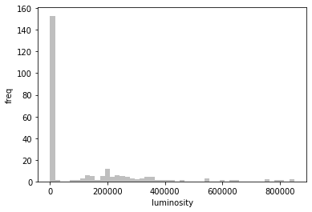

```python
sample = data.luminosity
xlab = 'luminosity'
ylab = 'freq'

bins = np.linspace(sample.min(), sample.max())
ax = plt.axes()
ax.set_xlabel(xlab)
ax.set_ylabel(ylab)
plt.hist(sample, bins, alpha=0.5, color='gray')
plt.show()
```

Or, more usefully, on a log scale:

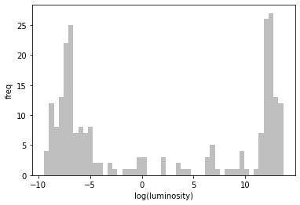

```python
sample = data.luminosity.apply(np.log)
xlab = 'log(luminosity)'
ylab = 'freq'

bins = np.linspace(sample.min(), sample.max())
ax = plt.axes()
ax.set_xlabel(xlab)
ax.set_ylabel(ylab)
plt.hist(sample, bins, alpha=0.5, color='gray')
plt.show()
```

We can split the data by another variable to compare different groups of stars.

For example, the following shows log(luminosity), grouped by type:

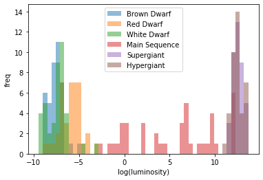

```python
sample = data.luminosity.apply(np.log)
grouped = sample.groupby(data.type)
xlab = 'log(luminosity)'
ylab = 'freq'

bins = np.linspace(sample.min(), sample.max())
ax = plt.axes()
ax.set_xlabel(xlab)
ax.set_ylabel(ylab)
grouped.apply(lambda x: plt.hist(x, bins, alpha=0.5, color = 'C' + str(x.name), label=type_key[x.name]))
ax.legend(loc='upper center')
plt.show()
```

## 2 - Comparing means of two groups

For now, let's look at only types 4 and 5 (supergiant and hypergiant). These are of particular interest to your supervisor, Dr Howe.

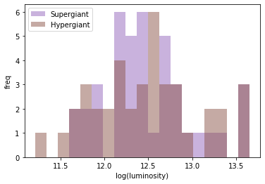

```python
types = [4,5]

sample = data.luminosity.apply(np.log)
grouped = sample.groupby(data.type)

xlab = 'log(luminosity)'
ylab = 'freq'

displayed = pd.concat([grouped.get_group(t) for t in types])
bins = np.linspace(displayed.min(), displayed.max(), 20)
ax = plt.axes()
ax.set_xlabel(xlab)
ax.set_ylabel(ylab)

plt.hist(grouped.get_group(types[0]), bins, alpha=0.5, label=type_key[types[0]], color='C' + str(types[0]))
plt.hist(grouped.get_group(types[1]), bins, alpha=0.5, label=type_key[types[1]], color='C' + str(types[1]))

ax.legend(loc='upper left')
plt.show()
```

Dr Howe has noticed that supergiants and hypergiants seem to have very similar luminosity distributions. She asks you to check whether they have the same mean.